**Denoising Autoencoder**

Initialized by Namjeong Lee  
Modified By Prof. Seungchul Lee  
http://iai.postech.ac.kr/  
Industrial AI Lab at POSTECH

Table of Contents

# 1. Unsupervised Learning

**Definition**

- Unsupervised learning refers to most attempts to extract information from a distribution that do not require human labor to annotate example
- Main task is to find the 'best' representation of the data

**Dimension Reduction**

- Attempt to compress as much information as possible in a smaller representation
- Preserve as much information as possible while obeying some constraint aimed at keeping the representation simpler

# 2. Autoencoders

It is like 'deep learning version' of unsupervised learning

**Definition**

- An autoencoder is a neural network that is trained to attempt to copy its input to its output
- The network consists of two parts: an **encoder** and a **decoder** that produce a reconstruction

**Encoder and Decoder**

- Encoder function : $h = f(x)$
- Decoder function : $x = g(h)$
- We learn to set $g\left(f(x)\right) = x$

[figure not shown]

**Advantage**

- We don't need any labels!
- Dimension reduction ; denoising, prevent overfitting, reduce the amount of calculation

# 3. Denoising Autoencoder

In denoising autoencoders, a random noise is deliberately added to the input and network is forced to reconstruct the unadulterated input. The decoder function learns to resist small changes in the input. This pretraining result in a robust neural network which is immune to noise in input up to a certain extent. We want to build the model to reconstruct the original signals from the noisy one.

When calculating the loss function, it is important to compare the output values with the original input, not with the corrupted input.

- MNIST example

[figure not shown]

## 3.1. Import Library

```python
import tensorflow as tf
import numpy as np
import matplotlib.pyplot as plt
from six.moves import cPickle
```

## 3.2. Load MNIST Data

```python
from tensorflow.examples.tutorials.mnist import input_data

#load mnist data
mnist = input_data.read_data_sets("MNIST_data/",one_hot = True)
```

```
Extracting MNIST_data/train-images-idx3-ubyte.gz
Extracting MNIST_data/train-labels-idx1-ubyte.gz
Extracting MNIST_data/t10k-images-idx3-ubyte.gz
Extracting MNIST_data/t10k-labels-idx1-ubyte.gz
```

```python
x_train_noisy = cPickle.load(open('./data_files/x_train_noisy.pkl','rb'))
x_train_original = cPickle.load(open('./data_files/original_train_mnist.pkl','rb'))
```

## 3.3. Define an Autoencoder Shape

- Input shape and latent variable shape
- Encoder shape
- Decoder shape

[figure not shown]

```python
#shape of input and latent variable

#shape of input
n_input = 28*28

#encoder shape
n_encoder = 128

n_latent = 32

#decoder shape
n_decoder = 128
```

## 3.4. Define Weights and Biases

```python
#define weights and biases

weights = {
    'encoder' : tf.Variable(tf.random_normal([n_input,n_encoder], stddev=0.1)),
    'latent' : tf.Variable(tf.random_normal([n_encoder,n_latent], stddev=0.1)),
    'decoder' : tf.Variable(tf.random_normal([n_latent,n_decoder], stddev = 0.1)),
    'reconst' : tf.Variable(tf.random_normal([n_decoder,n_input], stddev = 0.1))
}

biases = {
    'encoder' : tf.Variable(tf.random_normal([n_encoder], stddev=0.1)),
    'latent': tf.Variable(tf.random_normal([n_latent], stddev=0.1)),
    'decoder' : tf.Variable(tf.random_normal([n_decoder], stddev=0.1)),
    'reconst' : tf.Variable(tf.random_normal([n_input], stddev=0.1))
}

x = tf.placeholder(tf.float32, [None, n_input])
original = tf.placeholder(tf.float32, [None, n_input])
```

## 3.5. Build a Model

**Encoder**

- Simple ANN (MLP) model
- Use `RELU` for a nonlinear activation function
- `latent` is not applied with a nonlinear activation function

**Decoder**

[figure not shown]

```python
#encoder function
def encoder(x, weights, biases):
    encoder = tf.add(tf.matmul(x, weights['encoder']), biases['encoder'])
    encoder = tf.nn.relu(encoder)

    latent = tf.add(tf.matmul(encoder, weights['latent']), biases['latent'])

    return latent
```

```python
#decoder function
def decoder(latent, weights, biases):
    decoder = tf.add(tf.matmul(latent, weights['decoder']), biases['decoder'])
    decoder = tf.nn.relu(decoder)

    reconst = tf.add(tf.matmul(decoder, weights['reconst']), biases['reconst'])
# to improve reconstruction image performance, use a nonlinear activation with sigmoid
    reconst = tf.nn.sigmoid(reconst)
    return reconst
```

## 3.6. Define Loss, Initializer and Optimizer

When calculating the loss function, it is important to compare the output values with the original input, not with the corrupted input.

**Loss**

- Squared loss

$$ \frac{1}{N}\sum_{i=1}^{N} (t_{i} - y_{i})^2 $$

**Optimizer**

- AdamOptimizer: the most popular optimizer

**Initializer**

- Initialize all the empty variables

```python
LR = 0.0001

latent = encoder(x, weights, biases)
reconst = decoder(latent, weights, biases)
loss = tf.square(tf.subtract(original, reconst))
loss = tf.reduce_mean(loss)

optm = tf.train.AdamOptimizer(LR).minimize(loss)

init = tf.global_variables_initializer()
```

## 3.7. Iteration Process

[figure not shown]

## 3.8. Define Configuration

- Define parameters for training autoencoder
  - `n_batch` : batch size for stochastic gradient descent
  - `n_iter` : the number of training steps
  - `n_prt` : check loss for every `n_prt` iteration

```python
n_batch = 50
n_iter = 2500
n_prt = 250
```

## 3.9. Optimization

```python
sess = tf.Session()
sess.run(init)
```

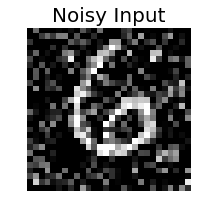

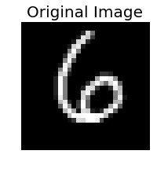

```python
idx = np.random.randint(mnist.train.images.shape[0], size = 1)
plt.figure(figsize = (5,3))
plt.imshow(x_train_noisy[idx].reshape(28,28),'gray')
plt.axis('off')
plt.title('Noisy Input', size = 20)
plt.show()
plt.figure(figsize = (5,3))
plt.imshow(x_train_original[idx].reshape(28,28),'gray')
plt.axis('off')
plt.title('Original Image', size = 20)
plt.show()
```

```python
for epoch in range(n_iter):
    idx = np.random.randint(mnist.train.images.shape[0], size = n_batch)
    noisy_x = [x_train_noisy[i] for i in idx]
    origin_x = [x_train_original[i] for i in idx]
    sess.run(optm, feed_dict = {x : noisy_x, original : origin_x})

    if epoch % n_prt == 0:
        cost = sess.run(loss, feed_dict={x: noisy_x, original: origin_x})
        print("Iter : {}".format(epoch))
        print("Cost : {}".format(cost))
```

```
Iter : 0
Cost : 0.2406778186559677
Iter : 250
Cost : 0.06820541620254517
Iter : 500
Cost : 0.06532975286245346
Iter : 750
Cost : 0.056198444217443466
Iter : 1000
Cost : 0.05052461102604866
Iter : 1250
Cost : 0.048406895250082016
Iter : 1500
Cost : 0.04062724858522415
Iter : 1750
Cost : 0.042036619037389755
Iter : 2000
Cost : 0.03710533678531647
Iter : 2250
Cost : 0.03386769816279411
```

## 3.10. Testing or Evaluation

- Test denoising effect of the autoencoder

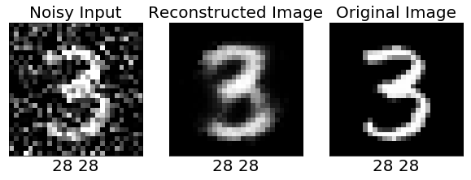

```python
idx = np.random.randint(x_train_noisy.shape[0])
noisy_x = x_train_noisy[idx].reshape((-1,784))
x_reconst = sess.run(reconst, feed_dict = {x : noisy_x})

fig = plt.figure(figsize=(10, 6))
ax1 = fig.add_subplot(1, 3, 1)
ax1.imshow(noisy_x.reshape(28, 28), 'gray')
ax1.set_title('Noisy Input', fontsize=20)
plt.xlabel('28 28', fontsize = 20)
ax1.set_xticks([])
ax1.set_yticks([])

ax2 = fig.add_subplot(1, 3, 2)
ax2.imshow(x_reconst.reshape(28, 28), 'gray')
ax2.set_title('Reconstructed Image', fontsize=20)
plt.xlabel('28 28', fontsize = 20)
ax2.set_xticks([])
ax2.set_yticks([])

ax3 = fig.add_subplot(1, 3, 3)
ax3.imshow(x_train_original[idx].reshape(28,28),'gray')
ax3.set_title('Original Image', fontsize = 20)
plt.xlabel('28 28', fontsize = 20)
ax3.set_xticks([])
ax3.set_yticks([])

plt.show()
```

```python
%%javascript
$.getScript('https://kmahelona.github.io/ipython_notebook_goodies/ipython_notebook_toc.js')
```